### Basic procedure of using machine learning package `mlr` in R

Package `mlr` provides an unified framework for machine learning experiments in R. This summary briefly explains the major steps of using `mlr` with an example that builds a random forest model on `mtcars` dataset. The [official tutorial](http://mlr-org.github.io/mlr-tutorial/devel/html/task/index.html) has more details of each step for various machine learning questions.

**prepare train and test data**

```r
set.seed(111)
sub <- sample(nrow(mtcars), round(0.7 * nrow(mtcars)))
train <- mtcars[sub,]
test <- mtcars[-sub,]
```

**define tasks and learner**  
Tasks define computer what kind of machine learning problem to solve with the data set. Learner specifies what algorithsm to use for the task.

```r
library(mlr)
# set up regression tasks to find the dependence of "mpg" on all predictors
taskTrain <- makeRegrTask(data = train, target = "mpg")
taskTest <- makeRegrTask(data = test, target = "mpg")

# choose random forest algorithsm for this regression task
learner <- makeLearner(cl = "regr.randomForest")
```

**set the ranges of hyper parameters**  
Random forest have two hyper parameters, `mtry` and `ntree`, that can be optimized. We need to specify their ranges or values within which the optimal ones are chosen.

```r
# set the range or values
ps <- makeParamSet(
    makeDiscreteParam ("mtry", values = 2:6),
    makeDiscreteParam("ntree", values = seq(200, 600, by = 100))
)
# specify the tune control method
ctrl <- makeTuneControlGrid()
```

**make resample method**  
Specify resample method for tuning hyper parameters.

```r
# 3 fold cross validation
rdesc <- makeResampleDesc(method = "CV", iters = 3L)
```

**prepare parallel computing**  
Speed up computing when the dataset is large.

```r
library(parallelMap)
# use 3 cpus
parallelStartSocket(3)
```

**tune hyper parameters**  
Find the optimal hyper parameters that minimize the performance measures, in the code below, root mean square error (rmse).

```r
res <- tuneParams(learner = learner,
                  task = taskTrain,
                  resampling = rdesc,
                  par.set = ps,
                  control = ctrl,
                  measures = rmse)
# view optimal hyper parameters
res$x
```

```
## $mtry
## [1] 6
##
## $ntree
## [1] 200
```

```r
# view optimization path
data.frame(res$opt.path)
```

```
##    mtry ntree rmse.test.rmse dob eol error.message exec.time
## 1     2   200       3.028501   1  NA          <NA>     0.087
## 2     3   200       2.924118   2  NA          <NA>     0.079
## 3     4   200       2.835633   3  NA          <NA>     0.105
## 4     5   200       2.821010   4  NA          <NA>     0.062
## 5     6   200       2.799634   5  NA          <NA>     0.054
## 6     2   300       2.935368   6  NA          <NA>     0.058
## 7     3   300       2.863163   7  NA          <NA>     0.060
## 8     4   300       2.845085   8  NA          <NA>     0.062
## 9     5   300       2.813375   9  NA          <NA>     0.067
## 10    6   300       2.866458  10  NA          <NA>     0.078
## 11    2   400       2.995358  11  NA          <NA>     0.064
## 12    3   400       2.888166  12  NA          <NA>     0.071
## 13    4   400       2.872027  13  NA          <NA>     0.066
## 14    5   400       2.869895  14  NA          <NA>     0.074
## 15    6   400       2.889227  15  NA          <NA>     0.063
## 16    2   500       2.936468  16  NA          <NA>     0.070
## 17    3   500       2.863063  17  NA          <NA>     0.070
## 18    4   500       2.865634  18  NA          <NA>     0.065
## 19    5   500       2.807692  19  NA          <NA>     0.076
## 20    6   500       2.807837  20  NA          <NA>     0.085
## 21    2   600       2.996206  21  NA          <NA>     0.070
## 22    3   600       2.882495  22  NA          <NA>     0.077
## 23    4   600       2.859900  23  NA          <NA>     0.079
## 24    5   600       2.857306  24  NA          <NA>     0.072
## 25    6   600       2.819000  25  NA          <NA>     0.054
```

**build model**  
Use the optimal hyper parameters to build the final model.

```r
# assign the optimal hyper paramters to the learner
learner <- setHyperPars(learner, par.vals = res$x)
# train the model
mod <- train(learner, taskTrain)
```

**make predictions**  
Apply the model to test data and make predictions.

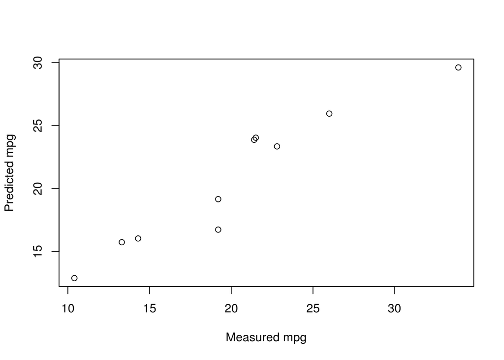

```r
pred <- predict(mod, taskTest)
# compare predicted and measured values
plot(pred$data$truth, pred$data$response,
     xlab = "Measured mpg", ylab = "Predicted mpg")
```